# Introduction

Lade has a script and is thinking of the director and main act that would bring her characters to life whilst making a large profit and gaining popularity. She contacts Kareemat(me) who is a Data Analyst in the movie industry on advise. Lade also informs Kareemat that her scripts genre is mostly Drama.

Kareemat carries out an analysis using the Movie Database dataset (tmdb-movies) which has relevant columns that would foster her analysis. The tmdb-movies dataset has several columns and rows featuring:

Columns Description: id, imdb_id : unique id or imdb id for each movie on TMDB popularity: a metric used to measure the popularity of the movie. budget:the total budget of the moviein USD. revenue:the total revenue of the movie in USD. original_title: the original title of the movie. cast:the names of the cast of the movie separated by "|". homepage: the website of the movie (if it existed). director:name(s) of the director(s) of the movie (separated by "|" if there are more than one director). tagline:a catchphrase describing the movie. keywords: keywords related to the movie. overview:summary of the plot of the movie. runtime:total runtime of the movie in minutes. genres: genres of the movie separated by "|". production_companies:production compan(y/ies) of the movie. release_date:release date of the movie. vote_count:number of voters of te movie. vote_average:the average user rating of the movie release_year:release year of the movie (from 1960 to 2015) budget_adj:the total budget of the moviein USD in terms of 2010 dollars, accounting for inflation over time. revenue_adj:the total budget of the movie in USD in terms of 2010 dollars, accounting for inflation over time. 4

Kareemat has to use this columns to advise Lade on:

1. Directors and Actors that would generate high profit for her scripts
2. Directors and Actors that would deliver very popular movies

## IMPORTING PACKAGES

**Kareemat starts by importing packages that would enable her run her analysis**

```python
import pandas as pd
import numpy as np
import matplotlib.pyplot as plt
import seaborn as sns
%matplotlib inline
```

## Defining Functions

```python
def group_max(df,x,y):
    '''
    This function is to give an output of recipients
    of the max count after being grouped.
    The first line of code creates a dataframe for each group
    with their counts.
    The second line of code gets the index of where
    the counts column is equal to the max count
    for each group.
    The dataframe corresponding to the rows is returned
    '''
    grp_cnt_df = df.groupby(x)[y].value_counts().rename('counts').reset_index()
    index = grp_cnt_df.groupby([x])['counts'].transform('max') == grp_cnt_df['counts']
    return grp_cnt_df.loc[index][[x,y,'counts']].set_index(x,y)
```

```python
def piechart(df,x,y,title):
    '''
    This function is to
    plot a piechart
    '''
    data = df[df[x] == y]['main_genre']
    data = data.value_counts()
    labels = data.index
    plt.figure(figsize=(10,6))
    data.plot(kind='pie',labels=labels,autopct='%1.2f%%')
    plt.title(title);
```

### Load data and printing out the first 5

```python
# Loading data and printing out a few lines
movies_df = pd.read_csv('tmdb-movies.csv')

#making a copy of my dataframe and then using the copy for my analysis subsequently
df = movies_df.copy()
df.head(5)
```

|  | id | imdb_id | popularity | budget | revenue | original_title | cast | homepage | director | tagline | ... | overview | runtime | genres | production_companies | release_date | vote_count | vote_average | release_year | budget_adj | revenue_adj |
| --- | --- | --- | --- | --- | --- | --- | --- | --- | --- | --- | --- | --- | --- | --- | --- | --- | --- | --- | --- | --- | --- |
| 0 | 135397 | tt0369610 | 32.985763 | 150000000 | 1513528810 | Jurassic World | Chris Pratt\|Bryce Dallas Howard\|Irrfan Khan\|Vi... | http://www.jurassicworld.com/ | Colin Trevorrow | The park is open. | ... | Twenty-two years after the events of Jurassic ... | 124 | Action\|Adventure\|Science Fiction\|Thriller | Universal Studios\|Amblin Entertainment\|Legenda... | 6/9/15 | 5562 | 6.5 | 2015 | 1.379999e+08 | 1.392446e+09 |
| 1 | 76341 | tt1392190 | 28.419936 | 150000000 | 378436354 | Mad Max: Fury Road | Tom Hardy\|Charlize Theron\|Hugh Keays-Byrne\|Nic... | http://www.madmaxmovie.com/ | George Miller | What a Lovely Day. | ... | An apocalyptic story set in the furthest reach... | 120 | Action\|Adventure\|Science Fiction\|Thriller | Village Roadshow Pictures\|Kennedy Miller Produ... | 5/13/15 | 6185 | 7.1 | 2015 | 1.379999e+08 | 3.481613e+08 |
| 2 | 262500 | tt2908446 | 13.112507 | 110000000 | 295238201 | Insurgent | Shailene Woodley\|Theo James\|Kate Winslet\|Ansel... | http://www.thedivergentseries.movie/#insurgent | Robert Schwentke | One Choice Can Destroy You | ... | Beatrice Prior must confront her inner demons ... | 119 | Adventure\|Science Fiction\|Thriller | Summit Entertainment\|Mandeville Films\|Red Wago... | 3/18/15 | 2480 | 6.3 | 2015 | 1.012000e+08 | 2.716190e+08 |
| 3 | 140607 | tt2488496 | 11.173104 | 200000000 | 2068178225 | Star Wars: The Force Awakens | Harrison Ford\|Mark Hamill\|Carrie Fisher\|Adam D... | http://www.starwars.com/films/star-wars-episod... | J.J. Abrams | Every generation has a story. | ... | Thirty years after defeating the Galactic Empi... | 136 | Action\|Adventure\|Science Fiction\|Fantasy | Lucasfilm\|Truenorth Productions\|Bad Robot | 12/15/15 | 5292 | 7.5 | 2015 | 1.839999e+08 | 1.902723e+09 |
| 4 | 168259 | tt2820852 | 9.335014 | 190000000 | 1506249360 | Furious 7 | Vin Diesel\|Paul Walker\|Jason Statham\|Michelle ... | http://www.furious7.com/ | James Wan | Vengeance Hits Home | ... | Deckard Shaw seeks revenge against Dominic Tor... | 137 | Action\|Crime\|Thriller | Universal Pictures\|Original Film\|Media Rights ... | 4/1/15 | 2947 | 7.3 | 2015 | 1.747999e+08 | 1.385749e+09 |

5 rows × 21 columns

```python
#to see the general overview of how each column looks like
df.info()
```

```
<class 'pandas.core.frame.DataFrame'>
RangeIndex: 10866 entries, 0 to 10865
Data columns (total 21 columns):
 #   Column                Non-Null Count  Dtype
---  ------                --------------  -----
 0   id                    10866 non-null  int64
 1   imdb_id               10856 non-null  object
 2   popularity            10866 non-null  float64
 3   budget                10866 non-null  int64
 4   revenue               10866 non-null  int64
 5   original_title        10866 non-null  object
 6   cast                  10790 non-null  object
 7   homepage              2936 non-null   object
 8   director              10822 non-null  object
 9   tagline               8042 non-null   object
 10  keywords              9373 non-null   object
 11  overview              10862 non-null  object
 12  runtime               10866 non-null  int64
 13  genres                10843 non-null  object
 14  production_companies  9836 non-null   object
 15  release_date          10866 non-null  object
 16  vote_count            10866 non-null  int64
 17  vote_average          10866 non-null  float64
 18  release_year          10866 non-null  int64
 19  budget_adj            10866 non-null  float64
 20  revenue_adj           10866 non-null  float64
dtypes: float64(4), int64(6), object(11)
memory usage: 1.7+ MB
```

# DATA WRANGLING

Kareemat assesses and cleans the dataset to ensure it is in good condition for analysis, she starts by removing duplicates, dropping unneeded columns, filling null values and creating new columns where she saw fit.

## DATA CLEANING

### DUPLICATES

```python
df.duplicated().sum() #Checked the amount of duplicate values
df.drop_duplicates(inplace=True) #dropping duplicate value
```

```python
df.info()
```

```
<class 'pandas.core.frame.DataFrame'>
Int64Index: 10865 entries, 0 to 10865
Data columns (total 21 columns):
 #   Column                Non-Null Count  Dtype
---  ------                --------------  -----
 0   id                    10865 non-null  int64
 1   imdb_id               10855 non-null  object
 2   popularity            10865 non-null  float64
 3   budget                10865 non-null  int64
 4   revenue               10865 non-null  int64
 5   original_title        10865 non-null  object
 6   cast                  10789 non-null  object
 7   homepage              2936 non-null   object
 8   director              10821 non-null  object
 9   tagline               8041 non-null   object
 10  keywords              9372 non-null   object
 11  overview              10861 non-null  object
 12  runtime               10865 non-null  int64
 13  genres                10842 non-null  object
 14  production_companies  9835 non-null   object
 15  release_date          10865 non-null  object
 16  vote_count            10865 non-null  int64
 17  vote_average          10865 non-null  float64
 18  release_year          10865 non-null  int64
 19  budget_adj            10865 non-null  float64
 20  revenue_adj           10865 non-null  float64
dtypes: float64(4), int64(6), object(11)
memory usage: 1.8+ MB
```

### Dropping Columns that will not be useful in analysis

```python
df.drop(['imdb_id', 'budget', 'revenue', 'homepage','tagline','keywords','overview','runtime','release_date','release_year'], axis = 1, inplace = True)

#I dropped columns budget and revenue and kept columns budget_adj and revenue_adj  because they account for inflation over time
```

```python
df.info()
```

```
<class 'pandas.core.frame.DataFrame'>
Int64Index: 10865 entries, 0 to 10865
Data columns (total 11 columns):
 #   Column                Non-Null Count  Dtype
---  ------                --------------  -----
 0   id                    10865 non-null  int64
 1   popularity            10865 non-null  float64
 2   original_title        10865 non-null  object
 3   cast                  10789 non-null  object
 4   director              10821 non-null  object
 5   genres                10842 non-null  object
 6   production_companies  9835 non-null   object
 7   vote_count            10865 non-null  int64
 8   vote_average          10865 non-null  float64
 9   budget_adj            10865 non-null  float64
 10  revenue_adj           10865 non-null  float64
dtypes: float64(4), int64(2), object(5)
memory usage: 1018.6+ KB
```

### Kareemat notices 4 columns(cast,director,genres and production_companies) have null values and decides to fill them

## Filling the rows which have columns with null values as unknown

Kareemat decided to fill rows instead of dropping them because there are over a thousand rows with null values for production_companies alone

```python
#Columns cast,director,genres and production companies null values are filled with unknown
df.fillna({'cast':'Unknown','director':'Unknown','genres':'Unknown','production_companies':'Unknown'},inplace=True)
```

```python
#confirming it has been filled
df.info()
```

```
<class 'pandas.core.frame.DataFrame'>
Int64Index: 10865 entries, 0 to 10865
Data columns (total 11 columns):
 #   Column                Non-Null Count  Dtype
---  ------                --------------  -----
 0   id                    10865 non-null  int64
 1   popularity            10865 non-null  float64
 2   original_title        10865 non-null  object
 3   cast                  10865 non-null  object
 4   director              10865 non-null  object
 5   genres                10865 non-null  object
 6   production_companies  10865 non-null  object
 7   vote_count            10865 non-null  int64
 8   vote_average          10865 non-null  float64
 9   budget_adj            10865 non-null  float64
 10  revenue_adj           10865 non-null  float64
dtypes: float64(4), int64(2), object(5)
memory usage: 1018.6+ KB
```

### Creating New Columns

In this dataset, the main columns of focus have multiple infos, Kareemat assumes the first info is the most important,so she picks that out and puts it in new columns for better analysis. Those columns include:

cast - the cast column has multiple people director - a good number of the movies have one directors but some have multiple genres - There are multiple genres as expected but I'm creating a new column for the first genre production_companies - Multiple production companies also

```python
#Assuming the lead act is the first written on the cast
#The first genre is the main genre
#The first production
df['lead_actor'] = df['cast'].str.split('|',expand=True)[0]
df['main_director'] = df['director'].str.split('|',expand=True)[0]
df['main_genre'] = df['genres'].str.split('|',expand=True)[0]
df['main_production_company'] = df['production_companies'].str.split('|',expand=True)[0]
df
```

|  | id | popularity | original_title | cast | director | genres | production_companies | vote_count | vote_average | budget_adj | revenue_adj | lead_actor | main_director | main_genre | main_production_company |
| --- | --- | --- | --- | --- | --- | --- | --- | --- | --- | --- | --- | --- | --- | --- | --- |
| 0 | 135397 | 32.985763 | Jurassic World | Chris Pratt\|Bryce Dallas Howard\|Irrfan Khan\|Vi... | Colin Trevorrow | Action\|Adventure\|Science Fiction\|Thriller | Universal Studios\|Amblin Entertainment\|Legenda... | 5562 | 6.5 | 1.379999e+08 | 1.392446e+09 | Chris Pratt | Colin Trevorrow | Action | Universal Studios |
| 1 | 76341 | 28.419936 | Mad Max: Fury Road | Tom Hardy\|Charlize Theron\|Hugh Keays-Byrne\|Nic... | George Miller | Action\|Adventure\|Science Fiction\|Thriller | Village Roadshow Pictures\|Kennedy Miller Produ... | 6185 | 7.1 | 1.379999e+08 | 3.481613e+08 | Tom Hardy | George Miller | Action | Village Roadshow Pictures |
| 2 | 262500 | 13.112507 | Insurgent | Shailene Woodley\|Theo James\|Kate Winslet\|Ansel... | Robert Schwentke | Adventure\|Science Fiction\|Thriller | Summit Entertainment\|Mandeville Films\|Red Wago... | 2480 | 6.3 | 1.012000e+08 | 2.716190e+08 | Shailene Woodley | Robert Schwentke | Adventure | Summit Entertainment |
| 3 | 140607 | 11.173104 | Star Wars: The Force Awakens | Harrison Ford\|Mark Hamill\|Carrie Fisher\|Adam D... | J.J. Abrams | Action\|Adventure\|Science Fiction\|Fantasy | Lucasfilm\|Truenorth Productions\|Bad Robot | 5292 | 7.5 | 1.839999e+08 | 1.902723e+09 | Harrison Ford | J.J. Abrams | Action | Lucasfilm |
| 4 | 168259 | 9.335014 | Furious 7 | Vin Diesel\|Paul Walker\|Jason Statham\|Michelle ... | James Wan | Action\|Crime\|Thriller | Universal Pictures\|Original Film\|Media Rights ... | 2947 | 7.3 | 1.747999e+08 | 1.385749e+09 | Vin Diesel | James Wan | Action | Universal Pictures |
| ... | ... | ... | ... | ... | ... | ... | ... | ... | ... | ... | ... | ... | ... | ... | ... |
| 10861 | 21 | 0.080598 | The Endless Summer | Michael Hynson\|Robert August\|Lord 'Tally Ho' B... | Bruce Brown | Documentary | Bruce Brown Films | 11 | 7.4 | 0.000000e+00 | 0.000000e+00 | Michael Hynson | Bruce Brown | Documentary | Bruce Brown Films |
| 10862 | 20379 | 0.065543 | Grand Prix | James Garner\|Eva Marie Saint\|Yves Montand\|Tosh... | John Frankenheimer | Action\|Adventure\|Drama | Cherokee Productions\|Joel Productions\|Douglas ... | 20 | 5.7 | 0.000000e+00 | 0.000000e+00 | James Garner | John Frankenheimer | Action | Cherokee Productions |
| 10863 | 39768 | 0.065141 | Beregis Avtomobilya | Innokentiy Smoktunovskiy\|Oleg Efremov\|Georgi Z... | Eldar Ryazanov | Mystery\|Comedy | Mosfilm | 11 | 6.5 | 0.000000e+00 | 0.000000e+00 | Innokentiy Smoktunovskiy | Eldar Ryazanov | Mystery | Mosfilm |
| 10864 | 21449 | 0.064317 | What's Up, Tiger Lily? | Tatsuya Mihashi\|Akiko Wakabayashi\|Mie Hama\|Joh... | Woody Allen | Action\|Comedy | Benedict Pictures Corp. | 22 | 5.4 | 0.000000e+00 | 0.000000e+00 | Tatsuya Mihashi | Woody Allen | Action | Benedict Pictures Corp. |
| 10865 | 22293 | 0.035919 | Manos: The Hands of Fate | Harold P. Warren\|Tom Neyman\|John Reynolds\|Dian... | Harold P. Warren | Horror | Norm-Iris | 15 | 1.5 | 1.276423e+05 | 0.000000e+00 | Harold P. Warren | Harold P. Warren | Horror | Norm-Iris |

10865 rows × 15 columns

## Kareemat also created a new column to see profits generated

```python
df['profit'] = df['revenue_adj'] - df['budget_adj']
df
```

|  | id | popularity | original_title | cast | director | genres | production_companies | vote_count | vote_average | budget_adj | revenue_adj | lead_actor | main_director | main_genre | main_production_company | profit |
| --- | --- | --- | --- | --- | --- | --- | --- | --- | --- | --- | --- | --- | --- | --- | --- | --- |
| 0 | 135397 | 32.985763 | Jurassic World | Chris Pratt\|Bryce Dallas Howard\|Irrfan Khan\|Vi... | Colin Trevorrow | Action\|Adventure\|Science Fiction\|Thriller | Universal Studios\|Amblin Entertainment\|Legenda... | 5562 | 6.5 | 1.379999e+08 | 1.392446e+09 | Chris Pratt | Colin Trevorrow | Action | Universal Studios | 1.254446e+09 |
| 1 | 76341 | 28.419936 | Mad Max: Fury Road | Tom Hardy\|Charlize Theron\|Hugh Keays-Byrne\|Nic... | George Miller | Action\|Adventure\|Science Fiction\|Thriller | Village Roadshow Pictures\|Kennedy Miller Produ... | 6185 | 7.1 | 1.379999e+08 | 3.481613e+08 | Tom Hardy | George Miller | Action | Village Roadshow Pictures | 2.101614e+08 |
| 2 | 262500 | 13.112507 | Insurgent | Shailene Woodley\|Theo James\|Kate Winslet\|Ansel... | Robert Schwentke | Adventure\|Science Fiction\|Thriller | Summit Entertainment\|Mandeville Films\|Red Wago... | 2480 | 6.3 | 1.012000e+08 | 2.716190e+08 | Shailene Woodley | Robert Schwentke | Adventure | Summit Entertainment | 1.704191e+08 |
| 3 | 140607 | 11.173104 | Star Wars: The Force Awakens | Harrison Ford\|Mark Hamill\|Carrie Fisher\|Adam D... | J.J. Abrams | Action\|Adventure\|Science Fiction\|Fantasy | Lucasfilm\|Truenorth Productions\|Bad Robot | 5292 | 7.5 | 1.839999e+08 | 1.902723e+09 | Harrison Ford | J.J. Abrams | Action | Lucasfilm | 1.718723e+09 |
| 4 | 168259 | 9.335014 | Furious 7 | Vin Diesel\|Paul Walker\|Jason Statham\|Michelle ... | James Wan | Action\|Crime\|Thriller | Universal Pictures\|Original Film\|Media Rights ... | 2947 | 7.3 | 1.747999e+08 | 1.385749e+09 | Vin Diesel | James Wan | Action | Universal Pictures | 1.210949e+09 |
| ... | ... | ... | ... | ... | ... | ... | ... | ... | ... | ... | ... | ... | ... | ... | ... | ... |
| 10861 | 21 | 0.080598 | The Endless Summer | Michael Hynson\|Robert August\|Lord 'Tally Ho' B... | Bruce Brown | Documentary | Bruce Brown Films | 11 | 7.4 | 0.000000e+00 | 0.000000e+00 | Michael Hynson | Bruce Brown | Documentary | Bruce Brown Films | 0.000000e+00 |
| 10862 | 20379 | 0.065543 | Grand Prix | James Garner\|Eva Marie Saint\|Yves Montand\|Tosh... | John Frankenheimer | Action\|Adventure\|Drama | Cherokee Productions\|Joel Productions\|Douglas ... | 20 | 5.7 | 0.000000e+00 | 0.000000e+00 | James Garner | John Frankenheimer | Action | Cherokee Productions | 0.000000e+00 |
| 10863 | 39768 | 0.065141 | Beregis Avtomobilya | Innokentiy Smoktunovskiy\|Oleg Efremov\|Georgi Z... | Eldar Ryazanov | Mystery\|Comedy | Mosfilm | 11 | 6.5 | 0.000000e+00 | 0.000000e+00 | Innokentiy Smoktunovskiy | Eldar Ryazanov | Mystery | Mosfilm | 0.000000e+00 |
| 10864 | 21449 | 0.064317 | What's Up, Tiger Lily? | Tatsuya Mihashi\|Akiko Wakabayashi\|Mie Hama\|Joh... | Woody Allen | Action\|Comedy | Benedict Pictures Corp. | 22 | 5.4 | 0.000000e+00 | 0.000000e+00 | Tatsuya Mihashi | Woody Allen | Action | Benedict Pictures Corp. | 0.000000e+00 |
| 10865 | 22293 | 0.035919 | Manos: The Hands of Fate | Harold P. Warren\|Tom Neyman\|John Reynolds\|Dian... | Harold P. Warren | Horror | Norm-Iris | 15 | 1.5 | 1.276423e+05 | 0.000000e+00 | Harold P. Warren | Harold P. Warren | Horror | Norm-Iris | -1.276423e+05 |

10865 rows × 16 columns

## Kareemat notices column budget_adj and revenue_adj have zero values

```python
df.tail(20)
```

|  | id | popularity | original_title | cast | director | genres | production_companies | vote_count | vote_average | budget_adj | revenue_adj | lead_actor | main_director | main_genre | main_production_company | profit |
| --- | --- | --- | --- | --- | --- | --- | --- | --- | --- | --- | --- | --- | --- | --- | --- | --- |
| 10846 | 17102 | 0.212716 | Dracula: Prince of Darkness | Christopher Lee\|Barbara Shelley\|Andrew Keir\|Fr... | Terence Fisher | Horror | Seven Arts Productions\|Hammer Film Productions | 16 | 5.7 | 0.000000e+00 | 0.000000e+00 | Christopher Lee | Terence Fisher | Horror | Seven Arts Productions | 0.000000e+00 |
| 10847 | 28763 | 0.034555 | Island of Terror | Peter Cushing\|Edward Judd\|Carole Gray\|Eddie By... | Terence Fisher | Science Fiction\|Horror | Planet Film Productions\|Protelco | 13 | 5.3 | 0.000000e+00 | 0.000000e+00 | Peter Cushing | Terence Fisher | Science Fiction | Planet Film Productions | 0.000000e+00 |
| 10848 | 2161 | 0.207257 | Fantastic Voyage | Stephen Boyd\|Raquel Welch\|Edmond O'Brien\|Donal... | Richard Fleischer | Adventure\|Science Fiction | Twentieth Century Fox Film Corporation | 42 | 6.7 | 3.436265e+07 | 8.061618e+07 | Stephen Boyd | Richard Fleischer | Adventure | Twentieth Century Fox Film Corporation | 4.625353e+07 |
| 10849 | 28270 | 0.206537 | Gambit | Michael Caine\|Shirley MacLaine\|Herbert Lom\|Joh... | Ronald Neame | Action\|Comedy\|Crime | Universal Pictures | 14 | 6.1 | 0.000000e+00 | 0.000000e+00 | Michael Caine | Ronald Neame | Action | Universal Pictures | 0.000000e+00 |
| 10850 | 26268 | 0.202473 | Harper | Paul Newman\|Lauren Bacall\|Julie Harris\|Arthur ... | Jack Smight | Action\|Drama\|Thriller\|Crime\|Mystery | Warner Bros. | 14 | 6.0 | 0.000000e+00 | 0.000000e+00 | Paul Newman | Jack Smight | Action | Warner Bros. | 0.000000e+00 |
| 10851 | 15347 | 0.342791 | Born Free | Virginia McKenna\|Bill Travers\|Geoffrey Keen\|Pe... | James Hill | Adventure\|Drama\|Action\|Family\|Foreign | High Road | 15 | 6.6 | 0.000000e+00 | 0.000000e+00 | Virginia McKenna | James Hill | Adventure | High Road | 0.000000e+00 |
| 10852 | 37301 | 0.227220 | A Big Hand for the Little Lady | Henry Fonda\|Joanne Woodward\|Jason Robards\|Paul... | Fielder Cook | Western | Eden Productions Inc. | 11 | 6.0 | 0.000000e+00 | 0.000000e+00 | Henry Fonda | Fielder Cook | Western | Eden Productions Inc. | 0.000000e+00 |
| 10853 | 15598 | 0.163592 | Alfie | Michael Caine\|Shelley Winters\|Millicent Martin... | Lewis Gilbert | Comedy\|Drama\|Romance | Unknown | 26 | 6.2 | 0.000000e+00 | 0.000000e+00 | Michael Caine | Lewis Gilbert | Comedy | Unknown | 0.000000e+00 |
| 10854 | 31602 | 0.146402 | The Chase | Marlon Brando\|Jane Fonda\|Robert Redford\|E.G. M... | Arthur Penn | Thriller\|Drama\|Crime | Horizon Pictures\|Columbia Pictures Corporation | 17 | 6.0 | 0.000000e+00 | 0.000000e+00 | Marlon Brando | Arthur Penn | Thriller | Horizon Pictures | 0.000000e+00 |
| 10855 | 13343 | 0.141026 | The Ghost & Mr. Chicken | Don Knotts\|Joan Staley\|Liam Redmond\|Dick Sarge... | Alan Rafkin | Comedy\|Family\|Mystery\|Romance | Universal Pictures | 14 | 6.1 | 4.702610e+06 | 0.000000e+00 | Don Knotts | Alan Rafkin | Comedy | Universal Pictures | -4.702610e+06 |
| 10856 | 20277 | 0.140934 | The Ugly Dachshund | Dean Jones\|Suzanne Pleshette\|Charles Ruggles\|K... | Norman Tokar | Comedy\|Drama\|Family | Walt Disney Pictures | 14 | 5.7 | 0.000000e+00 | 0.000000e+00 | Dean Jones | Norman Tokar | Comedy | Walt Disney Pictures | 0.000000e+00 |
| 10857 | 5921 | 0.131378 | Nevada Smith | Steve McQueen\|Karl Malden\|Brian Keith\|Arthur K... | Henry Hathaway | Action\|Western | Paramount Pictures\|Solar Productions\|Embassy P... | 10 | 5.9 | 0.000000e+00 | 0.000000e+00 | Steve McQueen | Henry Hathaway | Action | Paramount Pictures | 0.000000e+00 |
| 10858 | 31918 | 0.317824 | The Russians Are Coming, The Russians Are Coming | Carl Reiner\|Eva Marie Saint\|Alan Arkin\|Brian K... | Norman Jewison | Comedy\|War | The Mirisch Corporation | 11 | 5.5 | 0.000000e+00 | 0.000000e+00 | Carl Reiner | Norman Jewison | Comedy | The Mirisch Corporation | 0.000000e+00 |
| 10859 | 20620 | 0.089072 | Seconds | Rock Hudson\|Salome Jens\|John Randolph\|Will Gee... | John Frankenheimer | Mystery\|Science Fiction\|Thriller\|Drama | Gibraltar Productions\|Joel Productions\|John Fr... | 22 | 6.6 | 0.000000e+00 | 0.000000e+00 | Rock Hudson | John Frankenheimer | Mystery | Gibraltar Productions | 0.000000e+00 |
| 10860 | 5060 | 0.087034 | Carry On Screaming! | Kenneth Williams\|Jim Dale\|Harry H. Corbett\|Joa... | Gerald Thomas | Comedy | Peter Rogers Productions\|Anglo-Amalgamated Fil... | 13 | 7.0 | 0.000000e+00 | 0.000000e+00 | Kenneth Williams | Gerald Thomas | Comedy | Peter Rogers Productions | 0.000000e+00 |
| 10861 | 21 | 0.080598 | The Endless Summer | Michael Hynson\|Robert August\|Lord 'Tally Ho' B... | Bruce Brown | Documentary | Bruce Brown Films | 11 | 7.4 | 0.000000e+00 | 0.000000e+00 | Michael Hynson | Bruce Brown | Documentary | Bruce Brown Films | 0.000000e+00 |
| 10862 | 20379 | 0.065543 | Grand Prix | James Garner\|Eva Marie Saint\|Yves Montand\|Tosh... | John Frankenheimer | Action\|Adventure\|Drama | Cherokee Productions\|Joel Productions\|Douglas ... | 20 | 5.7 | 0.000000e+00 | 0.000000e+00 | James Garner | John Frankenheimer | Action | Cherokee Productions | 0.000000e+00 |
| 10863 | 39768 | 0.065141 | Beregis Avtomobilya | Innokentiy Smoktunovskiy\|Oleg Efremov\|Georgi Z... | Eldar Ryazanov | Mystery\|Comedy | Mosfilm | 11 | 6.5 | 0.000000e+00 | 0.000000e+00 | Innokentiy Smoktunovskiy | Eldar Ryazanov | Mystery | Mosfilm | 0.000000e+00 |
| 10864 | 21449 | 0.064317 | What's Up, Tiger Lily? | Tatsuya Mihashi\|Akiko Wakabayashi\|Mie Hama\|Joh... | Woody Allen | Action\|Comedy | Benedict Pictures Corp. | 22 | 5.4 | 0.000000e+00 | 0.000000e+00 | Tatsuya Mihashi | Woody Allen | Action | Benedict Pictures Corp. | 0.000000e+00 |
| 10865 | 22293 | 0.035919 | Manos: The Hands of Fate | Harold P. Warren\|Tom Neyman\|John Reynolds\|Dian... | Harold P. Warren | Horror | Norm-Iris | 15 | 1.5 | 1.276423e+05 | 0.000000e+00 | Harold P. Warren | Harold P. Warren | Horror | Norm-Iris | -1.276423e+05 |

```python
df[(df['budget_adj'] == 0) | (df['revenue_adj'] == 0) ].count()
#we can see that over 7000 rows have a budget or revenue as 0
```

```
id                         7011
popularity                 7011
original_title             7011
cast                       7011
director                   7011
genres                     7011
production_companies       7011
vote_count                 7011
vote_average               7011
budget_adj                 7011
revenue_adj                7011
lead_actor                 7011
main_director              7011
main_genre                 7011
main_production_company    7011
profit                     7011
dtype: int64
```

### Kareemat makes a copy of the dataframe and drop the rows with their budget or revenue as 0

```python
df2 = df.copy()
```

```python
df2
```

|  | id | popularity | original_title | cast | director | genres | production_companies | vote_count | vote_average | budget_adj | revenue_adj | lead_actor | main_director | main_genre | main_production_company | profit |
| --- | --- | --- | --- | --- | --- | --- | --- | --- | --- | --- | --- | --- | --- | --- | --- | --- |
| 0 | 135397 | 32.985763 | Jurassic World | Chris Pratt\|Bryce Dallas Howard\|Irrfan Khan\|Vi... | Colin Trevorrow | Action\|Adventure\|Science Fiction\|Thriller | Universal Studios\|Amblin Entertainment\|Legenda... | 5562 | 6.5 | 1.379999e+08 | 1.392446e+09 | Chris Pratt | Colin Trevorrow | Action | Universal Studios | 1.254446e+09 |
| 1 | 76341 | 28.419936 | Mad Max: Fury Road | Tom Hardy\|Charlize Theron\|Hugh Keays-Byrne\|Nic... | George Miller | Action\|Adventure\|Science Fiction\|Thriller | Village Roadshow Pictures\|Kennedy Miller Produ... | 6185 | 7.1 | 1.379999e+08 | 3.481613e+08 | Tom Hardy | George Miller | Action | Village Roadshow Pictures | 2.101614e+08 |
| 2 | 262500 | 13.112507 | Insurgent | Shailene Woodley\|Theo James\|Kate Winslet\|Ansel... | Robert Schwentke | Adventure\|Science Fiction\|Thriller | Summit Entertainment\|Mandeville Films\|Red Wago... | 2480 | 6.3 | 1.012000e+08 | 2.716190e+08 | Shailene Woodley | Robert Schwentke | Adventure | Summit Entertainment | 1.704191e+08 |
| 3 | 140607 | 11.173104 | Star Wars: The Force Awakens | Harrison Ford\|Mark Hamill\|Carrie Fisher\|Adam D... | J.J. Abrams | Action\|Adventure\|Science Fiction\|Fantasy | Lucasfilm\|Truenorth Productions\|Bad Robot | 5292 | 7.5 | 1.839999e+08 | 1.902723e+09 | Harrison Ford | J.J. Abrams | Action | Lucasfilm | 1.718723e+09 |
| 4 | 168259 | 9.335014 | Furious 7 | Vin Diesel\|Paul Walker\|Jason Statham\|Michelle ... | James Wan | Action\|Crime\|Thriller | Universal Pictures\|Original Film\|Media Rights ... | 2947 | 7.3 | 1.747999e+08 | 1.385749e+09 | Vin Diesel | James Wan | Action | Universal Pictures | 1.210949e+09 |
| ... | ... | ... | ... | ... | ... | ... | ... | ... | ... | ... | ... | ... | ... | ... | ... | ... |
| 10861 | 21 | 0.080598 | The Endless Summer | Michael Hynson\|Robert August\|Lord 'Tally Ho' B... | Bruce Brown | Documentary | Bruce Brown Films | 11 | 7.4 | 0.000000e+00 | 0.000000e+00 | Michael Hynson | Bruce Brown | Documentary | Bruce Brown Films | 0.000000e+00 |
| 10862 | 20379 | 0.065543 | Grand Prix | James Garner\|Eva Marie Saint\|Yves Montand\|Tosh... | John Frankenheimer | Action\|Adventure\|Drama | Cherokee Productions\|Joel Productions\|Douglas ... | 20 | 5.7 | 0.000000e+00 | 0.000000e+00 | James Garner | John Frankenheimer | Action | Cherokee Productions | 0.000000e+00 |
| 10863 | 39768 | 0.065141 | Beregis Avtomobilya | Innokentiy Smoktunovskiy\|Oleg Efremov\|Georgi Z... | Eldar Ryazanov | Mystery\|Comedy | Mosfilm | 11 | 6.5 | 0.000000e+00 | 0.000000e+00 | Innokentiy Smoktunovskiy | Eldar Ryazanov | Mystery | Mosfilm | 0.000000e+00 |
| 10864 | 21449 | 0.064317 | What's Up, Tiger Lily? | Tatsuya Mihashi\|Akiko Wakabayashi\|Mie Hama\|Joh... | Woody Allen | Action\|Comedy | Benedict Pictures Corp. | 22 | 5.4 | 0.000000e+00 | 0.000000e+00 | Tatsuya Mihashi | Woody Allen | Action | Benedict Pictures Corp. | 0.000000e+00 |
| 10865 | 22293 | 0.035919 | Manos: The Hands of Fate | Harold P. Warren\|Tom Neyman\|John Reynolds\|Dian... | Harold P. Warren | Horror | Norm-Iris | 15 | 1.5 | 1.276423e+05 | 0.000000e+00 | Harold P. Warren | Harold P. Warren | Horror | Norm-Iris | -1.276423e+05 |

10865 rows × 16 columns

```python
df2.shape
```

```
(10865, 16)
```

```python
#dropping rows with 0 budget or revenue
zero = df2[(df2['budget_adj'] == 0) | (df2['revenue_adj'] == 0)]
df2.drop(zero.index,inplace=True)
```

```python
shape = df2.shape
'Now I have {} rows and {} columns '.format(shape[0],shape[1])
```

```
'Now I have 3854 rows and 16 columns '
```

## Kareemat then decides to explore her dataset with 3854 rows as she is satisfied with her data wrangling

## Exploratory Data Analysis

```python
df2.describe()

#the minimum profit is a negative value,hence there are definitely losses
```

|  | id | popularity | vote_count | vote_average | budget_adj | revenue_adj | profit |
| --- | --- | --- | --- | --- | --- | --- | --- |
| count | 3854.000000 | 3854.000000 | 3854.000000 | 3854.000000 | 3.854000e+03 | 3.854000e+03 | 3.854000e+03 |
| mean | 39888.185262 | 1.191554 | 527.720291 | 6.168163 | 4.423999e+07 | 1.370647e+08 | 9.282470e+07 |
| std | 67222.527399 | 1.475162 | 879.956821 | 0.794920 | 4.480925e+07 | 2.161114e+08 | 1.940715e+08 |
| min | 5.000000 | 0.001117 | 10.000000 | 2.200000 | 9.693980e-01 | 2.370705e+00 | -4.139124e+08 |
| 25% | 6073.500000 | 0.462367 | 71.000000 | 5.700000 | 1.309053e+07 | 1.835735e+07 | -1.504995e+06 |
| 50% | 11321.500000 | 0.797511 | 204.000000 | 6.200000 | 3.001611e+07 | 6.173068e+07 | 2.737064e+07 |
| 75% | 38573.250000 | 1.368324 | 580.000000 | 6.700000 | 6.061307e+07 | 1.632577e+08 | 1.074548e+08 |
| max | 417859.000000 | 32.985763 | 9767.000000 | 8.400000 | 4.250000e+08 | 2.827124e+09 | 2.750137e+09 |

### Focusing on the profit aspect

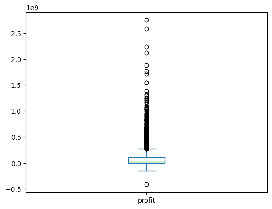

```python
df2['profit'].plot(kind='box');

#there are so many outliers,so i decide not to drop them
```

### Grouping profit into Loss, No Profit,Low Profit and High Profit

```python
df2['profit'].describe()
```

```
count    3.854000e+03
mean     9.282470e+07
std      1.940715e+08
min     -4.139124e+08
25%     -1.504995e+06
50%      2.737064e+07
75%      1.074548e+08
max      2.750137e+09
Name: profit, dtype: float64
```

```python
df2[df2['profit'] == 0].count()['profit']
#only 4 movies break even that is no profit or loss
```

```
4
```

```python
#This is done because I want to get the group of no profit and to group I need boundaries
#I get the minimum number after 0, so I can set it as the outer boundary while grouping
df2[df2['profit'] > 0]['profit'].min()
```

```
0.9360333527403597
```

### Grouping is done based on:

Loss: movies with less than zero profits No_Profit: movies with no profit Low_Profit: movies with profits lower than the median profits High_Profit: movies with profit hgher than the median profits

```python
bins=[-4.139124e+08,0,0.9360333527403597,2.737064e+07,2.750139e+09]
labels = ['Loss','No_Profit','Low_Profit','High_Profit']

df2['profit_class'] = pd.cut(df2['profit'],bins=bins, labels=labels,right=False)
df2
```

|  | id | popularity | original_title | cast | director | genres | production_companies | vote_count | vote_average | budget_adj | revenue_adj | lead_actor | main_director | main_genre | main_production_company | profit | profit_class |
| --- | --- | --- | --- | --- | --- | --- | --- | --- | --- | --- | --- | --- | --- | --- | --- | --- | --- |
| 0 | 135397 | 32.985763 | Jurassic World | Chris Pratt\|Bryce Dallas Howard\|Irrfan Khan\|Vi... | Colin Trevorrow | Action\|Adventure\|Science Fiction\|Thriller | Universal Studios\|Amblin Entertainment\|Legenda... | 5562 | 6.5 | 1.379999e+08 | 1.392446e+09 | Chris Pratt | Colin Trevorrow | Action | Universal Studios | 1.254446e+09 | High_Profit |
| 1 | 76341 | 28.419936 | Mad Max: Fury Road | Tom Hardy\|Charlize Theron\|Hugh Keays-Byrne\|Nic... | George Miller | Action\|Adventure\|Science Fiction\|Thriller | Village Roadshow Pictures\|Kennedy Miller Produ... | 6185 | 7.1 | 1.379999e+08 | 3.481613e+08 | Tom Hardy | George Miller | Action | Village Roadshow Pictures | 2.101614e+08 | High_Profit |
| 2 | 262500 | 13.112507 | Insurgent | Shailene Woodley\|Theo James\|Kate Winslet\|Ansel... | Robert Schwentke | Adventure\|Science Fiction\|Thriller | Summit Entertainment\|Mandeville Films\|Red Wago... | 2480 | 6.3 | 1.012000e+08 | 2.716190e+08 | Shailene Woodley | Robert Schwentke | Adventure | Summit Entertainment | 1.704191e+08 | High_Profit |
| 3 | 140607 | 11.173104 | Star Wars: The Force Awakens | Harrison Ford\|Mark Hamill\|Carrie Fisher\|Adam D... | J.J. Abrams | Action\|Adventure\|Science Fiction\|Fantasy | Lucasfilm\|Truenorth Productions\|Bad Robot | 5292 | 7.5 | 1.839999e+08 | 1.902723e+09 | Harrison Ford | J.J. Abrams | Action | Lucasfilm | 1.718723e+09 | High_Profit |
| 4 | 168259 | 9.335014 | Furious 7 | Vin Diesel\|Paul Walker\|Jason Statham\|Michelle ... | James Wan | Action\|Crime\|Thriller | Universal Pictures\|Original Film\|Media Rights ... | 2947 | 7.3 | 1.747999e+08 | 1.385749e+09 | Vin Diesel | James Wan | Action | Universal Pictures | 1.210949e+09 | High_Profit |
| ... | ... | ... | ... | ... | ... | ... | ... | ... | ... | ... | ... | ... | ... | ... | ... | ... | ... |
| 10822 | 396 | 0.670274 | Who's Afraid of Virginia Woolf? | Elizabeth Taylor\|Richard Burton\|George Segal\|S... | Mike Nichols | Drama | Chenault Productions | 74 | 7.5 | 5.038511e+07 | 2.266436e+08 | Elizabeth Taylor | Mike Nichols | Drama | Chenault Productions | 1.762585e+08 | High_Profit |
| 10828 | 5780 | 0.402730 | Torn Curtain | Paul Newman\|Julie Andrews\|Lila Kedrova\|HansjÃ¶... | Alfred Hitchcock | Mystery\|Thriller | Universal Pictures | 46 | 6.3 | 2.015404e+07 | 8.733419e+07 | Paul Newman | Alfred Hitchcock | Mystery | Universal Pictures | 6.718015e+07 | High_Profit |
| 10829 | 6644 | 0.395668 | El Dorado | John Wayne\|Robert Mitchum\|James Caan\|Charlene ... | Howard Hawks | Action\|Western | Paramount Pictures\|Laurel Productions | 36 | 6.9 | 3.125892e+07 | 4.030809e+07 | John Wayne | Howard Hawks | Action | Paramount Pictures | 9.049166e+06 | Low_Profit |
| 10835 | 5923 | 0.299911 | The Sand Pebbles | Steve McQueen\|Richard Attenborough\|Richard Cre... | Robert Wise | Action\|Adventure\|Drama\|War\|Romance | Twentieth Century Fox Film Corporation\|Solar P... | 28 | 7.0 | 8.061618e+07 | 1.343603e+08 | Steve McQueen | Robert Wise | Action | Twentieth Century Fox Film Corporation | 5.374412e+07 | High_Profit |
| 10848 | 2161 | 0.207257 | Fantastic Voyage | Stephen Boyd\|Raquel Welch\|Edmond O'Brien\|Donal... | Richard Fleischer | Adventure\|Science Fiction | Twentieth Century Fox Film Corporation | 42 | 6.7 | 3.436265e+07 | 8.061618e+07 | Stephen Boyd | Richard Fleischer | Adventure | Twentieth Century Fox Film Corporation | 4.625353e+07 | High_Profit |

3854 rows × 17 columns

```python
# Reconfirming if I have the same number of No profit as I had for zeros(which was 4)
df2.query('profit_class == "No_Profit"').count()
#It correlates
```

```
id                         4
popularity                 4
original_title             4
cast                       4
director                   4
genres                     4
production_companies       4
vote_count                 4
vote_average               4
budget_adj                 4
revenue_adj                4
lead_actor                 4
main_director              4
main_genre                 4
main_production_company    4
profit                     4
profit_class               4
dtype: int64
```

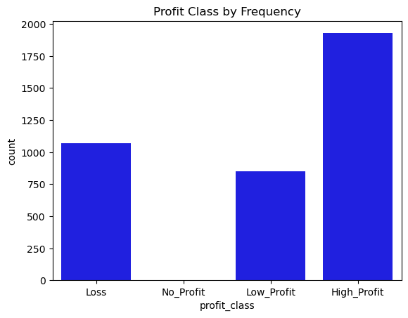

```python
sns.countplot(x='profit_class', data = df2, color='b')
plt.title('Profit Class by Frequency');
```

## Focusing on the popularity aspect

Since I won't be analysing the revenue_adj,budget_adj or profit columns here, I can use my original dataframe(df) with 10865 rows

```python
df.shape
```

```
(10865, 16)
```

```python
df['popularity'].describe()
```

```
count    10865.000000
mean         0.646446
std          1.000231
min          0.000065
25%          0.207575
50%          0.383831
75%          0.713857
max         32.985763
Name: popularity, dtype: float64
```

```python
df['popularity'].value_counts()
```

```
0.557155    2
0.214587    2
0.187319    2
0.060425    2
0.078482    2
           ..
0.430790    1
0.429826    1
0.424885    1
0.424880    1
0.035919    1
Name: popularity, Length: 10814, dtype: int64
```

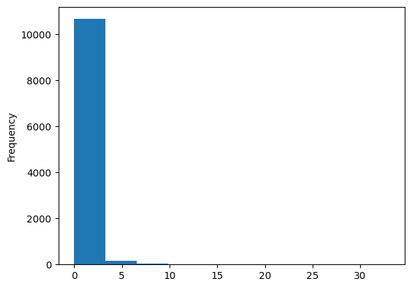

```python
df['popularity'].plot(kind='hist')
```

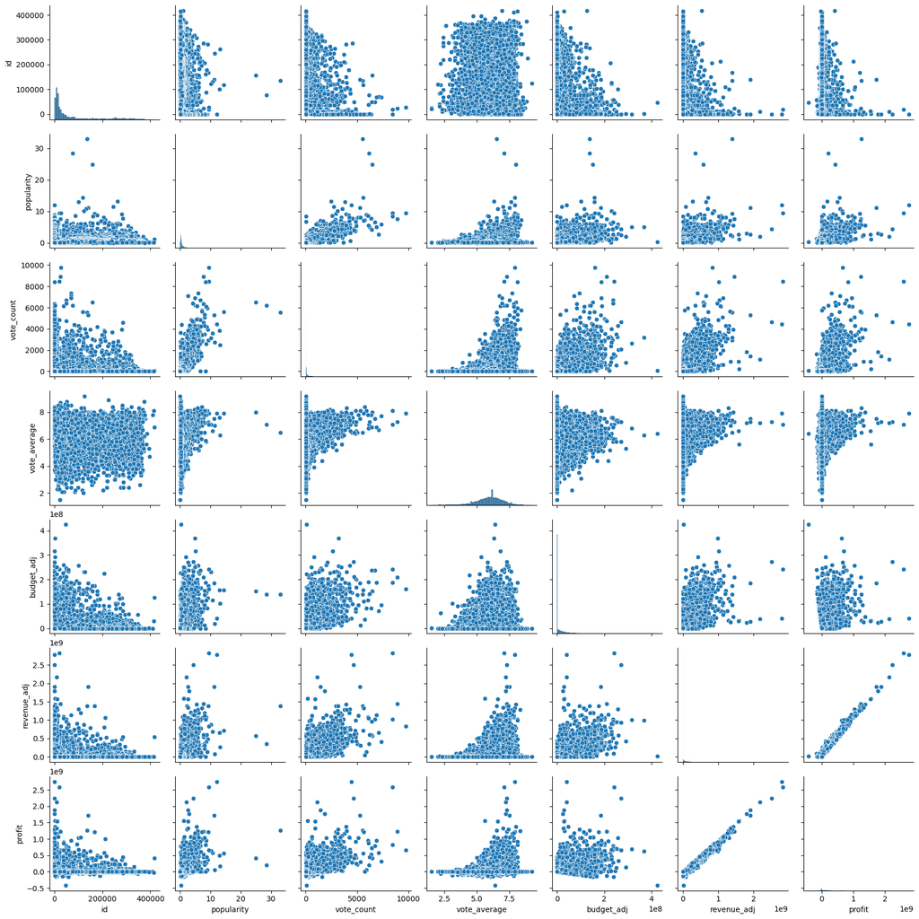

```python
sns.pairplot(df);
#I can see over 3 outliers on the popularity column
#I want to use a boxplot to confirm my suspicision
```

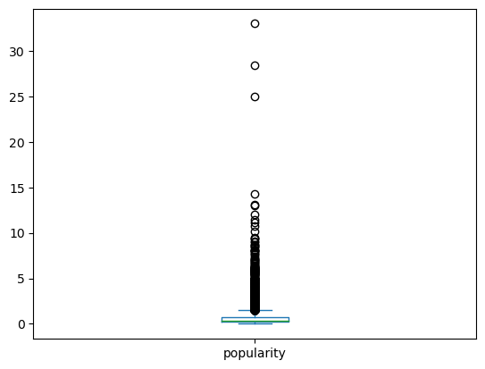

```python
df['popularity'].plot(kind = 'box');
```

### There a lot of outliers so I can't remove them but there are 3 extreme outliers(>20). I would create a dataframe excluding them to carryout my analysis

```python
#making a copy of the df dataframe
df3 = df.copy()
df3
```

|  | id | popularity | original_title | cast | director | genres | production_companies | vote_count | vote_average | budget_adj | revenue_adj | lead_actor | main_director | main_genre | main_production_company | profit |
| --- | --- | --- | --- | --- | --- | --- | --- | --- | --- | --- | --- | --- | --- | --- | --- | --- |
| 0 | 135397 | 32.985763 | Jurassic World | Chris Pratt\|Bryce Dallas Howard\|Irrfan Khan\|Vi... | Colin Trevorrow | Action\|Adventure\|Science Fiction\|Thriller | Universal Studios\|Amblin Entertainment\|Legenda... | 5562 | 6.5 | 1.379999e+08 | 1.392446e+09 | Chris Pratt | Colin Trevorrow | Action | Universal Studios | 1.254446e+09 |
| 1 | 76341 | 28.419936 | Mad Max: Fury Road | Tom Hardy\|Charlize Theron\|Hugh Keays-Byrne\|Nic... | George Miller | Action\|Adventure\|Science Fiction\|Thriller | Village Roadshow Pictures\|Kennedy Miller Produ... | 6185 | 7.1 | 1.379999e+08 | 3.481613e+08 | Tom Hardy | George Miller | Action | Village Roadshow Pictures | 2.101614e+08 |
| 2 | 262500 | 13.112507 | Insurgent | Shailene Woodley\|Theo James\|Kate Winslet\|Ansel... | Robert Schwentke | Adventure\|Science Fiction\|Thriller | Summit Entertainment\|Mandeville Films\|Red Wago... | 2480 | 6.3 | 1.012000e+08 | 2.716190e+08 | Shailene Woodley | Robert Schwentke | Adventure | Summit Entertainment | 1.704191e+08 |
| 3 | 140607 | 11.173104 | Star Wars: The Force Awakens | Harrison Ford\|Mark Hamill\|Carrie Fisher\|Adam D... | J.J. Abrams | Action\|Adventure\|Science Fiction\|Fantasy | Lucasfilm\|Truenorth Productions\|Bad Robot | 5292 | 7.5 | 1.839999e+08 | 1.902723e+09 | Harrison Ford | J.J. Abrams | Action | Lucasfilm | 1.718723e+09 |
| 4 | 168259 | 9.335014 | Furious 7 | Vin Diesel\|Paul Walker\|Jason Statham\|Michelle ... | James Wan | Action\|Crime\|Thriller | Universal Pictures\|Original Film\|Media Rights ... | 2947 | 7.3 | 1.747999e+08 | 1.385749e+09 | Vin Diesel | James Wan | Action | Universal Pictures | 1.210949e+09 |
| ... | ... | ... | ... | ... | ... | ... | ... | ... | ... | ... | ... | ... | ... | ... | ... | ... |
| 10861 | 21 | 0.080598 | The Endless Summer | Michael Hynson\|Robert August\|Lord 'Tally Ho' B... | Bruce Brown | Documentary | Bruce Brown Films | 11 | 7.4 | 0.000000e+00 | 0.000000e+00 | Michael Hynson | Bruce Brown | Documentary | Bruce Brown Films | 0.000000e+00 |
| 10862 | 20379 | 0.065543 | Grand Prix | James Garner\|Eva Marie Saint\|Yves Montand\|Tosh... | John Frankenheimer | Action\|Adventure\|Drama | Cherokee Productions\|Joel Productions\|Douglas ... | 20 | 5.7 | 0.000000e+00 | 0.000000e+00 | James Garner | John Frankenheimer | Action | Cherokee Productions | 0.000000e+00 |
| 10863 | 39768 | 0.065141 | Beregis Avtomobilya | Innokentiy Smoktunovskiy\|Oleg Efremov\|Georgi Z... | Eldar Ryazanov | Mystery\|Comedy | Mosfilm | 11 | 6.5 | 0.000000e+00 | 0.000000e+00 | Innokentiy Smoktunovskiy | Eldar Ryazanov | Mystery | Mosfilm | 0.000000e+00 |
| 10864 | 21449 | 0.064317 | What's Up, Tiger Lily? | Tatsuya Mihashi\|Akiko Wakabayashi\|Mie Hama\|Joh... | Woody Allen | Action\|Comedy | Benedict Pictures Corp. | 22 | 5.4 | 0.000000e+00 | 0.000000e+00 | Tatsuya Mihashi | Woody Allen | Action | Benedict Pictures Corp. | 0.000000e+00 |
| 10865 | 22293 | 0.035919 | Manos: The Hands of Fate | Harold P. Warren\|Tom Neyman\|John Reynolds\|Dian... | Harold P. Warren | Horror | Norm-Iris | 15 | 1.5 | 1.276423e+05 | 0.000000e+00 | Harold P. Warren | Harold P. Warren | Horror | Norm-Iris | -1.276423e+05 |

10865 rows × 16 columns

```python
#Filtering rows with their popularity greater than 20
greater_20 = df3[df3['popularity'] > 20]
greater_20
#the dataframe below confirms there are 3 extreme outliers
```

|  | id | popularity | original_title | cast | director | genres | production_companies | vote_count | vote_average | budget_adj | revenue_adj | lead_actor | main_director | main_genre | main_production_company | profit |
| --- | --- | --- | --- | --- | --- | --- | --- | --- | --- | --- | --- | --- | --- | --- | --- | --- |
| 0 | 135397 | 32.985763 | Jurassic World | Chris Pratt\|Bryce Dallas Howard\|Irrfan Khan\|Vi... | Colin Trevorrow | Action\|Adventure\|Science Fiction\|Thriller | Universal Studios\|Amblin Entertainment\|Legenda... | 5562 | 6.5 | 1.379999e+08 | 1.392446e+09 | Chris Pratt | Colin Trevorrow | Action | Universal Studios | 1.254446e+09 |
| 1 | 76341 | 28.419936 | Mad Max: Fury Road | Tom Hardy\|Charlize Theron\|Hugh Keays-Byrne\|Nic... | George Miller | Action\|Adventure\|Science Fiction\|Thriller | Village Roadshow Pictures\|Kennedy Miller Produ... | 6185 | 7.1 | 1.379999e+08 | 3.481613e+08 | Tom Hardy | George Miller | Action | Village Roadshow Pictures | 2.101614e+08 |
| 629 | 157336 | 24.949134 | Interstellar | Matthew McConaughey\|Jessica Chastain\|Anne Hath... | Christopher Nolan | Adventure\|Drama\|Science Fiction | Paramount Pictures\|Legendary Pictures\|Warner B... | 6498 | 8.0 | 1.519800e+08 | 5.726906e+08 | Matthew McConaughey | Christopher Nolan | Adventure | Paramount Pictures | 4.207106e+08 |

```python
#Dropping these outliers
df3.drop(greater_20.index,inplace=True)
```

```python
df3.shape
#Getting the number of rows in the dataframe after the outliers have been dropped
```

```
(10862, 16)
```

```python
df3.describe()
```

|  | id | popularity | vote_count | vote_average | budget_adj | revenue_adj | profit |
| --- | --- | --- | --- | --- | --- | --- | --- |
| count | 10862.000000 | 10862.000000 | 10862.000000 | 10862.000000 | 1.086200e+04 | 1.086200e+04 | 1.086200e+04 |
| mean | 66050.642976 | 0.638674 | 215.779967 | 5.974673 | 1.751534e+07 | 5.117022e+07 | 3.365488e+07 |
| std | 92140.198156 | 0.882601 | 567.375372 | 0.934989 | 3.424901e+07 | 1.439697e+08 | 1.246209e+08 |
| min | 5.000000 | 0.000065 | 10.000000 | 1.500000 | 0.000000e+00 | 0.000000e+00 | -4.139124e+08 |
| 25% | 10593.750000 | 0.207549 | 17.000000 | 5.400000 | 0.000000e+00 | 0.000000e+00 | 0.000000e+00 |
| 50% | 20652.500000 | 0.383818 | 38.000000 | 6.000000 | 0.000000e+00 | 0.000000e+00 | 0.000000e+00 |
| 75% | 75556.750000 | 0.713181 | 145.000000 | 6.600000 | 2.080566e+07 | 3.367755e+07 | 1.287502e+07 |
| max | 417859.000000 | 14.311205 | 9767.000000 | 9.200000 | 4.250000e+08 | 2.827124e+09 | 2.750137e+09 |

### Grouping popularity into classes such as:

Not Popular - Below 25% percentile Barely Popular - Below 50% percentile(i.e below median) Popular- Below 75% percentile and above the median Very Popular - Above 75% percentile

```python
bins = (0,0.207549,0.383818,0.713181,14.311207)
labels = ('Not Popular','Barely Popular','Popular','Very Popular')

df3['popularity_class'] = pd.cut(df3['popularity'],bins=bins,labels=labels,right=False)
df3.head()
```

|  | id | popularity | original_title | cast | director | genres | production_companies | vote_count | vote_average | budget_adj | revenue_adj | lead_actor | main_director | main_genre | main_production_company | profit | popularity_class |
| --- | --- | --- | --- | --- | --- | --- | --- | --- | --- | --- | --- | --- | --- | --- | --- | --- | --- |
| 2 | 262500 | 13.112507 | Insurgent | Shailene Woodley\|Theo James\|Kate Winslet\|Ansel... | Robert Schwentke | Adventure\|Science Fiction\|Thriller | Summit Entertainment\|Mandeville Films\|Red Wago... | 2480 | 6.3 | 1.012000e+08 | 2.716190e+08 | Shailene Woodley | Robert Schwentke | Adventure | Summit Entertainment | 1.704191e+08 | Very Popular |
| 3 | 140607 | 11.173104 | Star Wars: The Force Awakens | Harrison Ford\|Mark Hamill\|Carrie Fisher\|Adam D... | J.J. Abrams | Action\|Adventure\|Science Fiction\|Fantasy | Lucasfilm\|Truenorth Productions\|Bad Robot | 5292 | 7.5 | 1.839999e+08 | 1.902723e+09 | Harrison Ford | J.J. Abrams | Action | Lucasfilm | 1.718723e+09 | Very Popular |
| 4 | 168259 | 9.335014 | Furious 7 | Vin Diesel\|Paul Walker\|Jason Statham\|Michelle ... | James Wan | Action\|Crime\|Thriller | Universal Pictures\|Original Film\|Media Rights ... | 2947 | 7.3 | 1.747999e+08 | 1.385749e+09 | Vin Diesel | James Wan | Action | Universal Pictures | 1.210949e+09 | Very Popular |
| 5 | 281957 | 9.110700 | The Revenant | Leonardo DiCaprio\|Tom Hardy\|Will Poulter\|Domhn... | Alejandro González Iñárritu | Western\|Drama\|Adventure\|Thriller | Regency Enterprises\|Appian Way\|CatchPlay\|Anony... | 3929 | 7.2 | 1.241999e+08 | 4.903142e+08 | Leonardo DiCaprio | Alejandro González Iñárritu | Western | Regency Enterprises | 3.661143e+08 | Very Popular |
| 6 | 87101 | 8.654359 | Terminator Genisys | Arnold Schwarzenegger\|Jason Clarke\|Emilia Clar... | Alan Taylor | Science Fiction\|Action\|Thriller\|Adventure | Paramount Pictures\|Skydance Productions | 2598 | 5.8 | 1.425999e+08 | 4.053551e+08 | Arnold Schwarzenegger | Alan Taylor | Science Fiction | Paramount Pictures | 2.627551e+08 | Very Popular |

```python
df3.info()
```

```
<class 'pandas.core.frame.DataFrame'>
Int64Index: 10862 entries, 2 to 10865
Data columns (total 17 columns):
 #   Column                   Non-Null Count  Dtype
---  ------                   --------------  -----
 0   id                       10862 non-null  int64
 1   popularity               10862 non-null  float64
 2   original_title           10862 non-null  object
 3   cast                     10862 non-null  object
 4   director                 10862 non-null  object
 5   genres                   10862 non-null  object
 6   production_companies     10862 non-null  object
 7   vote_count               10862 non-null  int64
 8   vote_average             10862 non-null  float64
 9   budget_adj               10862 non-null  float64
 10  revenue_adj              10862 non-null  float64
 11  lead_actor               10862 non-null  object
 12  main_director            10862 non-null  object
 13  main_genre               10862 non-null  object
 14  main_production_company  10862 non-null  object
 15  profit                   10862 non-null  float64
 16  popularity_class         10862 non-null  category
dtypes: category(1), float64(5), int64(2), object(9)
memory usage: 1.4+ MB
```

```python
df3['popularity_class'].value_counts()
```

```
Not Popular       2716
Very Popular      2716
Barely Popular    2715
Popular           2715
Name: popularity_class, dtype: int64
```

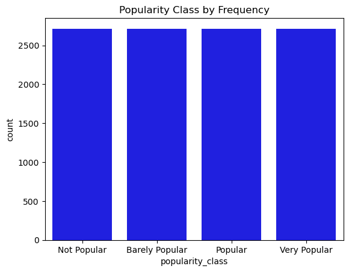

```python
sns.countplot(x='popularity_class', data = df3, color='b')
plt.title('Popularity Class by Frequency');
```

# Question 1

### Is the profit influenced by factors such as the genres, production_companies, cast and director?

### Comparing profit class against the lead actors to determine which actor makes the most profits

Question: Which actors makes the most high profits?

## To answer this question, I used a function created at the beginning of these notebook, this will:

1. Create a dataframe with the count for each group of profit class and the corresponding lead acts
2. Get the index of the max value/count for each profit class group
3. Use the index to select those rows

```python
group_max(df2,'profit_class','lead_actor')
```

| profit_class | lead_actor | counts |
| --- | --- | --- |
| Loss | Nicolas Cage | 16 |
| No_Profit | Guillaume Canet | 1 |
| No_Profit | Laurent Baffie | 1 |
| No_Profit | Sylvester Stallone | 1 |
| No_Profit | Unknown | 1 |
| Low_Profit | Robert De Niro | 7 |
| High_Profit | Tom Cruise | 25 |
| High_Profit | Tom Hanks | 25 |

```python
df2['lead_actor'].value_counts().head(20)
#actors and the number of movies they acted
```

```
Nicolas Cage             37
Bruce Willis             32
Johnny Depp              30
Sylvester Stallone       29
Tom Hanks                28
Denzel Washington        28
Robert De Niro           28
Tom Cruise               27
Arnold Schwarzenegger    26
Adam Sandler             24
Jim Carrey               23
Eddie Murphy             23
Harrison Ford            23
Keanu Reeves             22
Matt Damon               22
John Travolta            21
Ben Stiller              20
Kevin Costner            20
Michael Douglas          19
George Clooney           19
Name: lead_actor, dtype: int64
```

## Conclusion

Tom Hanks and Tom Cruise's movies have the highest number of movies with high profits Tom Hanks has 25 out of 28 of his movies being high profit Tom Cruise has 25 out of 27 of his movies being high profit

Nicolas Cage has 16 out of 37(about 43%) movies he acted as a loss i.e. 43% of the movies he acted were a loss

If we compare their ratios, Tom Cruise actually has a higher number of movies with high profits

```python
df2[df2['lead_actor'] == 'Tom Cruise']['main_genre'].value_counts()

#Tom Cruise acts mostly drama
```

```
Drama        10
Action        7
Adventure     6
Comedy        3
Crime         1
Name: main_genre, dtype: int64
```

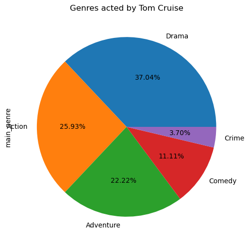

```python
piechart(df2,'lead_actor','Tom Cruise','Genres acted by Tom Cruise')

#Tom Cruise acts mostly drama
```

```python
df2[df2['lead_actor'] == 'Tom Hanks']['main_genre'].value_counts()

#Tom Hanks acts more of Comedy
```

```
Comedy       12
Thriller      4
Animation     4
Drama         4
Fantasy       2
Action        1
Adventure     1
Name: main_genre, dtype: int64
```

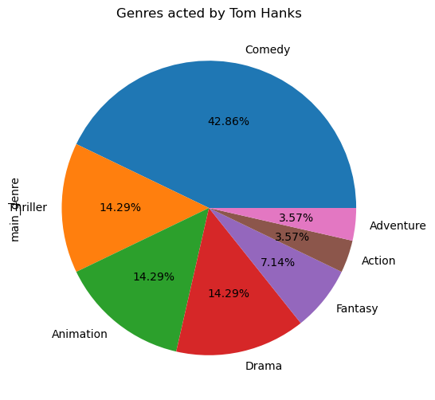

```python
piechart(df2,'lead_actor','Tom Hanks','Genres acted by Tom Hanks')
#Tom Hanks acts more of Comedy
```

### Comparing profit class against the genres to determine if genres influences profits

Question: Which genres give the most high profits?

## To answer this question, I used a function created at the beginning of these notebook, this will:

1. Create a dataframe with the count for each group of profit class and the corresponding main genres
2. Get the index of the max value/count for each profit class group
3. Use the index to select those rows

```python
group_max(df2,'profit_class','main_genre')
```

| profit_class | main_genre | counts |
| --- | --- | --- |
| Loss | Drama | 322 |
| No_Profit | Comedy | 2 |
| Low_Profit | Comedy | 213 |
| High_Profit | Comedy | 386 |

```python
df2.groupby(['profit_class'])['main_genre'].value_counts().groupby(level=0).nlargest(3)

#this is done to get the top 3 counts for each profit_class
```

```
profit_class  profit_class  main_genre
Loss          Loss          Drama          322
                            Action         206
                            Comedy         186
No_Profit     No_Profit     Comedy           2
                            Documentary      1
                            Drama            1
Low_Profit    Low_Profit    Comedy         213
                            Drama          206
                            Action         130
High_Profit   High_Profit   Comedy         386
                            Drama          361
                            Action         353
Name: main_genre, dtype: int64
```

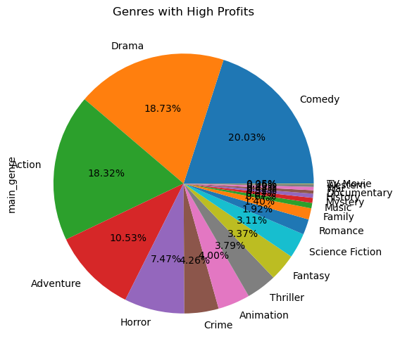

```python
piechart(df2,'profit_class','High_Profit','Genres with High Profits')
```

## Conclusion

Comedy,Drama and Action yield high profit We can see a larger number of comedy movies yield profit and lesser yield losses A large number of drama movies also yield profits If you are considering what genre of movie you should shoot and will most likely yield a profit, comedy is your go to

## Comparing Profits with directors

Question: Which director makes the most highest profit?

## To answer this question, I used a function created at the beginning of these notebook, this will:

1. Create a dataframe with the count for each group of profit class and the corresponding main acts
2. Get the index of the max value/count for each profit class group
3. Use the index to select those rows

```python
group_max(df2,'profit_class','main_director')
```

| profit_class | main_director | counts |
| --- | --- | --- |
| Loss | Renny Harlin | 9 |
| No_Profit | Dylan Avery | 1 |
| No_Profit | Laurent Baffie | 1 |
| No_Profit | Norman Jewison | 1 |
| No_Profit | Tristan Aurouet | 1 |
| Low_Profit | Kevin Smith | 8 |
| High_Profit | Steven Spielberg | 26 |

```python
df2['main_director'].value_counts().head()
```

```
Steven Spielberg    27
Clint Eastwood      24
Ridley Scott        21
Woody Allen         18
Martin Scorsese     17
Name: main_director, dtype: int64
```

### Conclusion

We can see that Steven Spielberg is a great director 26 out of 27 of his movies fall into high profit

Let's check out what genre he mostly directed

```python
df2[df2['main_director'] == 'Steven Spielberg']['main_genre'].value_counts()
#He directs a variety of genres but mostly drama and adventure
# he can be a go to for whatever genre you wish to act
```

```
Drama              9
Adventure          9
Action             3
Science Fiction    2
Thriller           1
Comedy             1
Fantasy            1
Horror             1
Name: main_genre, dtype: int64
```

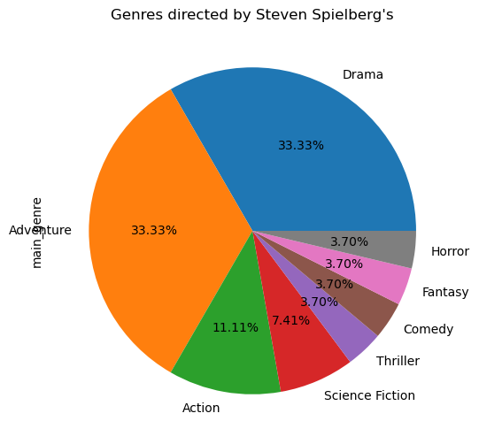

```python
piechart(df2,'main_director','Steven Spielberg','Genres directed by Steven Spielberg\'s')

#He directs a variety of genres but mostly drama and adventure
# he can be a go to for whatever genre you wish to act
```

### Comparing profit class against production company to determine if production_company influences profits

Question: Which production_company generates the most high profits?

## To answer this question, I used a function created at the beginning of these notebook, this will:

1. Create a dataframe with the count for each group of profit class and the corresponding main production company
2. Get the index of the max value/count for each profit class group
3. Use the index to select those rows

```python
group_max(df2,'profit_class','main_production_company')
```

| profit_class | main_production_company | counts |
| --- | --- | --- |
| Loss | Paramount Pictures | 49 |
| No_Profit | Laurent Baffie Productions | 1 |
| No_Profit | Louder Than Words | 1 |
| No_Profit | StudioCanal | 1 |
| No_Profit | chateau productions | 1 |
| Low_Profit | Paramount Pictures | 46 |
| Low_Profit | Universal Pictures | 46 |
| High_Profit | Universal Pictures | 191 |

# Question 2

### Does the popularity of the movie depend on director, cast or genres?

## Comparing popularity with the main genre

Question: Which genre is the most popular?

## To answer this question, I used a function created at the beginning of these notebook, this will:

1. Create a dataframe with the count for each group of popularity class and the corresponding main acts
2. Get the index of the max value/count for each popularity class group
3. Use the index to select those rows

```python
group_max(df3,'popularity_class','main_genre')
```

| popularity_class | main_genre | counts |
| --- | --- | --- |
| Not Popular | Comedy | 613 |
| Barely Popular | Drama | 678 |
| Popular | Drama | 673 |
| Very Popular | Drama | 518 |

```python
df3.groupby(['popularity_class'])['main_genre'].value_counts().groupby(level=0).nlargest(3)

#getting the top 3 genres for each popularity class
```

```
popularity_class  popularity_class  main_genre
Not Popular       Not Popular       Comedy        613
                                    Drama         584
                                    Action        293
Barely Popular    Barely Popular    Drama         678
                                    Comedy        590
                                    Action        392
Popular           Popular           Drama         673
                                    Comedy        602
                                    Action        419
Very Popular      Very Popular      Drama         518
                                    Comedy        514
                                    Action        484
Name: main_genre, dtype: int64
```

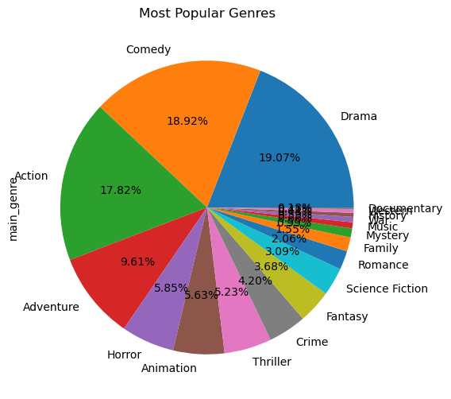

```python
piechart(df3,'popularity_class','Very Popular','Most Popular Genres')
```

### Conclusion

Drama, Comedy and Action are the most popular genres

## Comparing popularity to the lead act

Question: Which lead actor is the most popular?

## To answer this question, I used a function created at the beginning of these notebook, this will:

1. Create a dataframe with the count for each group of popularity class and the corresponding lead acts
2. Get the index of the max value/count for each popularity class group
3. Use the index to select those rows

```python
group_max(df3,'popularity_class','lead_actor')
```

| popularity_class | lead_actor | counts |
| --- | --- | --- |
| Not Popular | Unknown | 56 |
| Barely Popular | Steven Seagal | 18 |
| Popular | Jean-Claude Van Damme | 21 |
| Very Popular | Johnny Depp | 28 |
| Very Popular | Nicolas Cage | 28 |

## Conclusions

Movies with Johnny Depp and Nicolas Cage featured or rather as the main act had the most popular movies Although Nicolas Cage had a lot of losses,he is still the most popular

## Comparing popularity to the main director

Question: Which director was the most popular?

## To answer this question, I used a function created at the beginning of these notebook, this will:

1. Create a dataframe with the count for each group of popularity class and the corresponding main director
2. Get the index of the max value/count for each popularity class group
3. Use the index to select those rows

```python
group_max(df3,'popularity_class','main_director')
```

| popularity_class | main_director | counts |
| --- | --- | --- |
| Not Popular | Unknown | 35 |
| Barely Popular | Barry Levinson | 9 |
| Barely Popular | Norman Jewison | 9 |
| Popular | Woody Allen | 25 |
| Very Popular | Steven Spielberg | 22 |

## Conclusion

Steven Spielberg is the most popular director

# Findings

1. Steven Spielberg is the most popular director and also the most profitable director
2. Steven Spielberg's is good in a variety of genres but his main genres are drama and adventure
3. Tom Cruise is one of the most profitable actors with his main genre being drama
4. Tom Hanks is also one of the most profitable actors with his main genre being comedy
5. Drama,Action and Comedy are all very profitable and popular genres
6. The most popular actors are Johnny Depp and Nicolas Sage
7. Nicolas Sage is the actor with the most losses
8. Renny Harlin is the director with the most losses
9. Universal Pictures production company had the most profit

## Limitations

1. Assuming the first values in columns cast,director,genres and production_companies were the most important, therefore this analysis does not cover the successive values in each of these columns
2. The Dependent variables in this analysis(i.e. popularity ad profit) had a lot of outliers so they were not dropped
3. Columns revenue_adj and budget_adj had a lot of zero values which had to be dropped
4. Columns cast,director,genres and production_companies which had null values were filled with unknown
5. There were a large number of drama, action and comedy genres in the dataset

## Kareemat's Advise to Lade

It will be safe option for Lade to take her script to Steven Spielberg with her lead actor being Tom Cruise since it is a drama. She can also decide to add little comedy and bring on Tom Hanks as a supporting act. As a plus she should consider using Universal Pictures production company.

```python
df.to_csv('tmdb-movies-final.csv')
```

## Source

I improved my code making reference to some corrections by the reviewer